# Visualization of RNAseq data analysis

Ludmila Danilova & Joe Tandurella

2025-03-31

Vizualization for the paper using saved results from the RNAseq analysis. The results that will go to the paper as supplementary tables and figures are saved in the Analysis/Data/RNAseq/2024-01-22_LN folder.

# Load data

Load expression counts and sample annotation from CBR analysis (deidentified data with sample annotation from the Nature Cancer paper)

```
## [1] 22955    37
```

# PCA

## Final sample numbers

```
## [1] "Sample Numbers"
```

|  | Baseline | C1D1 | Week_8 |
| --- | --- | --- | --- |
| NonResponder | 10 | 11 | 5 |
| Responder | 4 | 5 | 2 |
|  | 14 | 16 | 7 |

```
## The number of paired samples between  Baseline  and  C1D1 : 12
## The number of paired samples between  Baseline  and  Week_8 : 4
## The number of paired samples between  C1D1  and  Week_8 : 5
```

```
##
##    Anterior_Chest_Wall    L_Abdominal_Omentum        L_Axillary_Node
##                      2                      2                      3
##               L_Breast           L_Chest_Wall         L_Hepatic_Mass
##                      2                      5                      4
##                  Liver                   Lung        Lung_Right_Lobe
##                      2                      1                      2
##  R_Anterior_Eighth_Rib        R_Axillary_Node               R_Breast
##                      1                      4                      2
##         R_Hepatic_Lobe           R_Iliac_Node R_Pelvic_Sidewall_Node
##                      4                      1                      1
## Superficial_Lymph_Node
##                      1
```

```
##
##     Breast Chest_Wall      Liver       Lung Lymph_Node    Omentum
##          4          8         10          3         10          2
```

```
##
## Baseline     C1D1   Week_8
##       14       16        7
```

```
##
##              HR+ TNBC
##   Breast       2    2
##   Chest_Wall   3    5
##   Liver        8    2
##   Lung         0    3
##   Lymph_Node   4    6
##   Omentum      2    0
```

|  | Baseline | C1D1 | Week_8 |  |
| --- | --- | --- | --- | --- |
| Breast | 2 | 2 | 0 | 4 |
| Chest_Wall | 3 | 3 | 2 | 8 |
| Liver | 4 | 4 | 2 | 10 |
| Lung | 0 | 2 | 1 | 3 |
| Lymph_Node | 4 | 4 | 2 | 10 |
| Omentum | 1 | 1 | 0 | 2 |

|  | NonResponder | Responder |  |
| --- | --- | --- | --- |
| Breast | 4 | 0 | 4 |
| Chest_Wall | 4 | 4 | 8 |
| Liver | 10 | 0 | 10 |
| Lung | 1 | 2 | 3 |
| Lymph_Node | 5 | 5 | 10 |
| Omentum | 2 | 0 | 2 |

```
##
##        NonResponder Responder
##   HR+            17         2
##   TNBC            9         9
```

```
##
##            NonResponder Responder
##   Baseline           10         4
##   C1D1               11         5
##   Week_8              5         2
```

```
##
##            HR+ TNBC
##   Baseline   7    7
##   C1D1       8    8
##   Week_8     4    3
```

```
## [1] "Responders:"
```

```
##               Timepoint
## RECIST         Baseline C1D1 Week_8
##   NonResponder        0    0      0
##   Responder           4    5      2
```

```
## The number of paired samples between  Baseline  and  C1D1 : 4
## The number of paired samples between  Baseline  and  Week_8 : 1
## The number of paired samples between  C1D1  and  Week_8 : 2
```

```
## [1] "Non-responders:"
```

```
##               Timepoint
## RECIST         Baseline C1D1 Week_8
##   NonResponder       10   11      5
##   Responder           0    0      0
```

```
## The number of paired samples between  Baseline  and  C1D1 : 8
## The number of paired samples between  Baseline  and  Week_8 : 3
## The number of paired samples between  C1D1  and  Week_8 : 3
```

# Time DE

## Baseline vs C1D1

paired analysis

```
## The number of paired samples between  Baseline  and  C1D1 : 12
## The number of paired samples between  Baseline  and  Week_8 : 4
## The number of paired samples between  C1D1  and  Week_8 : 5
```

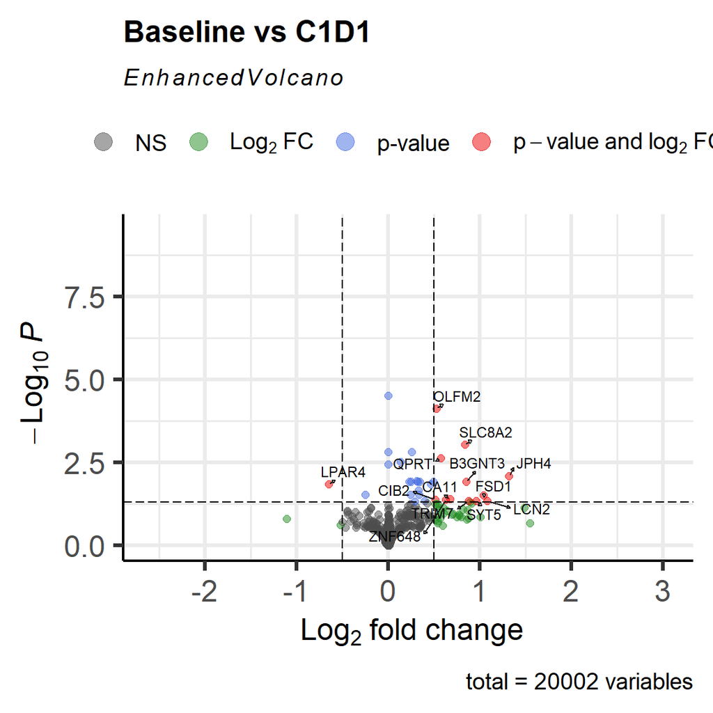

```
## The number of significantly DE genes:
##  13
## The number of down- and up-regulated genes:
##  1 12
## The top up-regulated genes:
##  JPH4 LCN2 FSD1 SYT5 TRIM7 B3GNT3 SLC8A2 CA11 ZNF648 QPRT OLFM2 CIB2
## The top down-regulated genes:
##  LPAR4
```

### Heatmap of Baseline vs C1D1

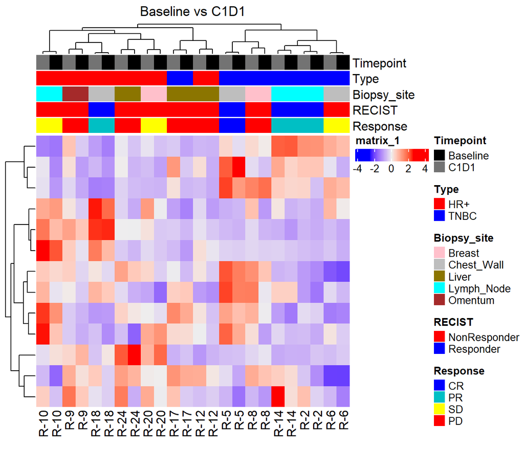

## C1D1 vs Week_8

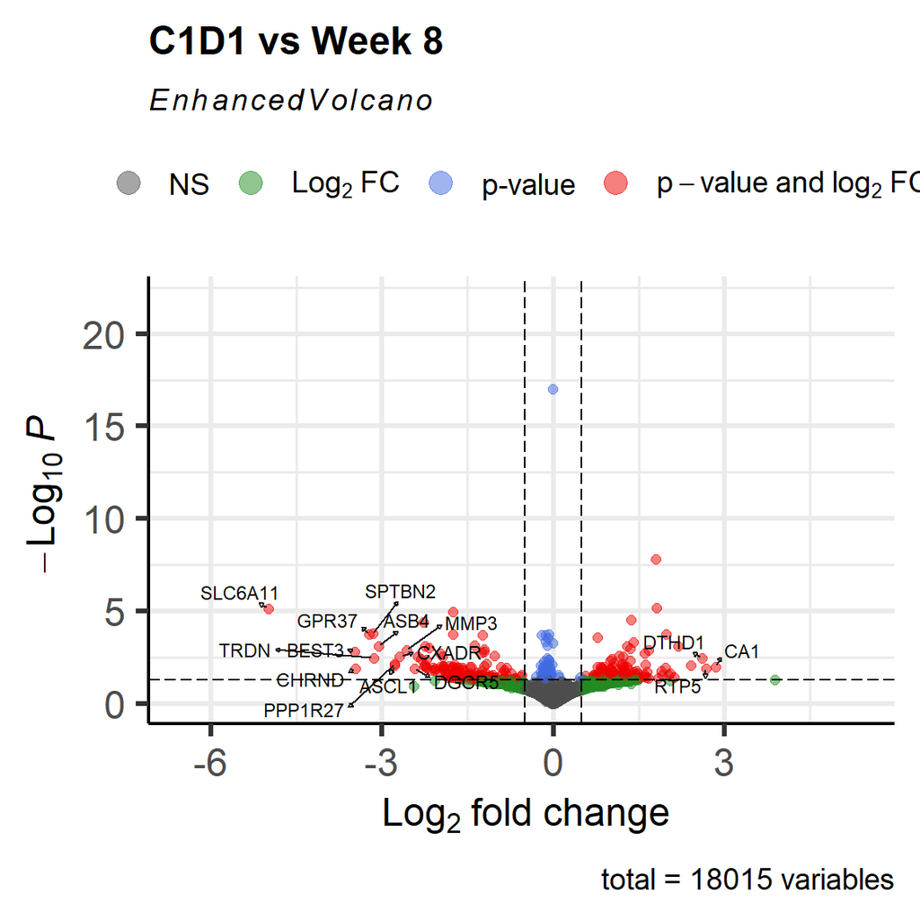

```
## The number of significantly DE genes:
##  231
## The number of down- and up-regulated genes:
##  127 104
## The top up-regulated genes:
##  CA1 RTP5 DTHD1 CXCL13 CXCR5 CPB1 HBA1 ATP6V0D2 ADAM33 SIRPD IFNG ABCB5 TNFRSF13B SIDT1 PRDM8 IL2 FGF7 SLC40A1 CXCR6 TOX2 GLIS1 PDCD1 UBASH3A PIANP HOXA2 RAB33A HLA-DPB2 INSL3 CAMK4 MDGA1 SAMD3 NAALAD2 HIF3A MAMDC2 NTNG2 LOC728392 FAIM3 L1TD1 FGD3 KCNMA1 PARP8 IGDCC4 ZNF154 ALS2CR11 YPEL4 RHOH WD…
## The top down-regulated genes:
##  SLC6A11 BEST3 CHRND GPR37 SPTBN2 TRDN ASB4 ASCL1 PPP1R27 CXADR MMP3 DGCR5 CBS SLC25A10 COLEC10 GPT CTSV DHCR7 IQGAP3 TMEM139 PLEK2 SIX2 GRB14 CLDN1 LINC00473 SERINC2 FAM64A RNF128 NUP62CL TNNI2 GCAT WDR62 RIPK4 RASL10B IL22RA1 LOC101927746 DEFB1 TMEM97 TK1 FAM132B TRIM72 ITPKA NGEF NIPAL1 LRP2 C…
```

### Heatmap of C1D1 vs Week_8

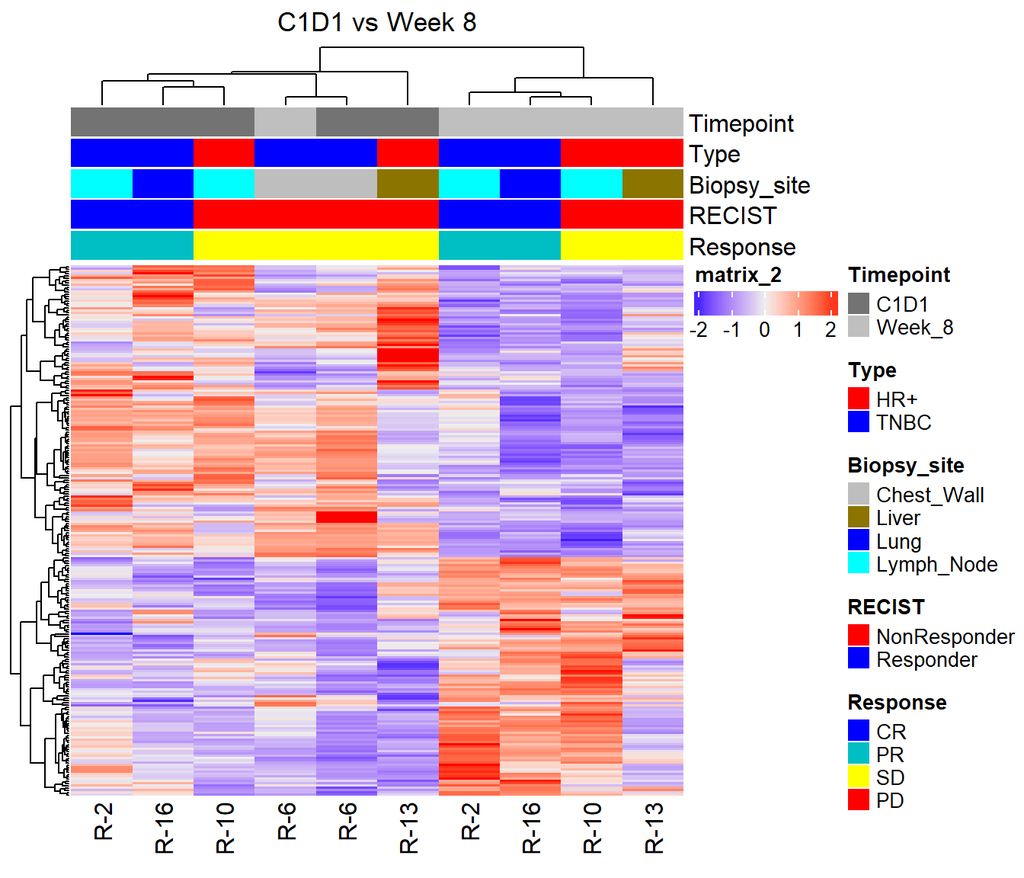

## Baseline vs Week_8

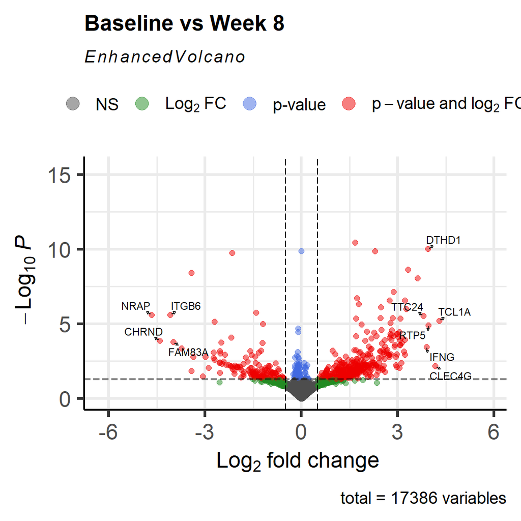

```
## The number of significantly DE genes:
##  495
## The number of down- and up-regulated genes:
##  133 362
## The top up-regulated genes:
##  TCL1A CLEC4G RTP5 DTHD1 IFNG TTC24 SH2D1A PDCD1 TIGIT GZMK ZNF831 GZMH CXCL13 CXCL9 FCRL3 KLRC4-KLRK1 CXCR2P1 SIT1 CD3D GPR174 FCAMR SIRPG THEMIS CD8A TRAT1 CPA5 TBX21 GZMB IDO2 CXCR6 GPR171 CTLA4 ICOS BCL11B IKZF3 LCK CD3G PYHIN1 TOX ITK CLEC10A CD8B FASLG CST7 EOMES UBD LY9 CD3E SLAMF6 BEND4 S…
## The top down-regulated genes:
##  NRAP CHRND ITGB6 FAM83A GPR115 LMOD2 CYP24A1 MYPN PRSS56 TNS4 PPP1R27 C3orf52 FAM83B MMP1 ADAMTS8 CKM MIR205HG PDZK1 BEST3 COL4A6 CLDN1 WT1 TACSTD2 CST2 AARD GAL CTSV PRKAA2 COL4A5 MYOM3 CA3 KCNK15 HGFAC LMOD3 EPHX4 ST6GALNAC2 DCDC2 ESM1 GABRD KLHL30 LRP1B LOC285556 SLC27A6 SYT12 ANKRD1 SIX2 CIA…
```

### Heatmap of Baseline vs Week_8

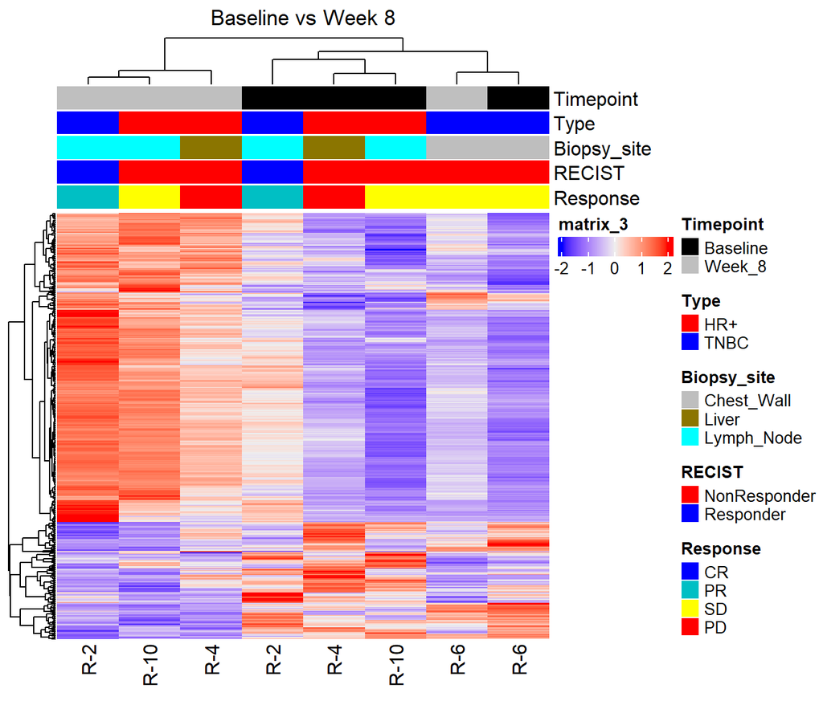

## Hallmark Pathway analysis

### dot plot

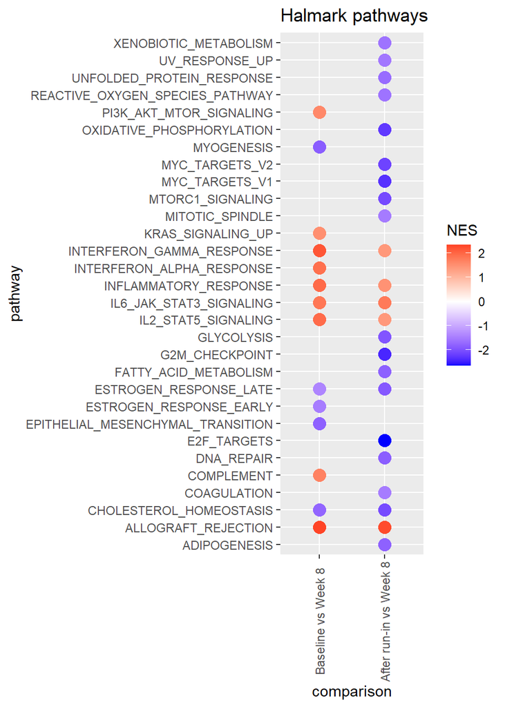

## Significant pathways and significant DE genes

Intersection of immune pathways and top DE genes to highlight some genes

```
## [1] "Common significant pathways:"
```

```
## [1] "HALLMARK_ALLOGRAFT_REJECTION"       "HALLMARK_CHOLESTEROL_HOMEOSTASIS"
## [3] "HALLMARK_ESTROGEN_RESPONSE_LATE"    "HALLMARK_IL2_STAT5_SIGNALING"
## [5] "HALLMARK_IL6_JAK_STAT3_SIGNALING"   "HALLMARK_INFLAMMATORY_RESPONSE"
## [7] "HALLMARK_INTERFERON_GAMMA_RESPONSE"
```

```
## [1] "Common significant genes:"
```

```
##  [1] "CHRND"   "RTP5"    "DTHD1"   "IFNG"    "PDCD1"   "CXCL13"  "CXCR6"
##  [8] "PPP1R27" "UBASH3A" "SIRPD"   "BEST3"   "CLDN1"   "TOX2"    "CTSV"
## [15] "CXCR5"   "RHOH"    "SIX2"    "FAIM3"   "CAMK4"   "CIART"   "PRDM8"
## [22] "SAMD3"   "RAB33A"  "TNNI2"   "NGEF"    "GRB14"   "KLHL31"  "RNF43"
## [29] "GPR37"   "AGAP2"   "SLC40A1" "ELAVL2"  "ZBTB32"  "KCNMA1"  "PARP8"
## [36] "ANXA2R"  "NTNG2"   "COL27A1" "VAV3"    "IGFBP2"  "TRAF1"   "MDGA1"
```

```
## [1] "HALLMARK_ALLOGRAFT_REJECTION"
## [1] "CXCL13" "IFNG"
## [1] "HALLMARK_CHOLESTEROL_HOMEOSTASIS"
## character(0)
## [1] "HALLMARK_ESTROGEN_RESPONSE_LATE"
## character(0)
## [1] "HALLMARK_IL2_STAT5_SIGNALING"
## [1] "RHOH"  "TRAF1"
## [1] "HALLMARK_IL6_JAK_STAT3_SIGNALING"
## [1] "CXCL13"
## [1] "HALLMARK_INFLAMMATORY_RESPONSE"
## [1] "CXCR6"
## [1] "HALLMARK_INTERFERON_GAMMA_RESPONSE"
## character(0)
```

# RECIST DE

For this DE, we will be doing a DE analysis to compare responder v nonresponder.

## Responder vs Nonresponder (Baseline)

```
##
## NonResponder    Responder
##           10            4
```

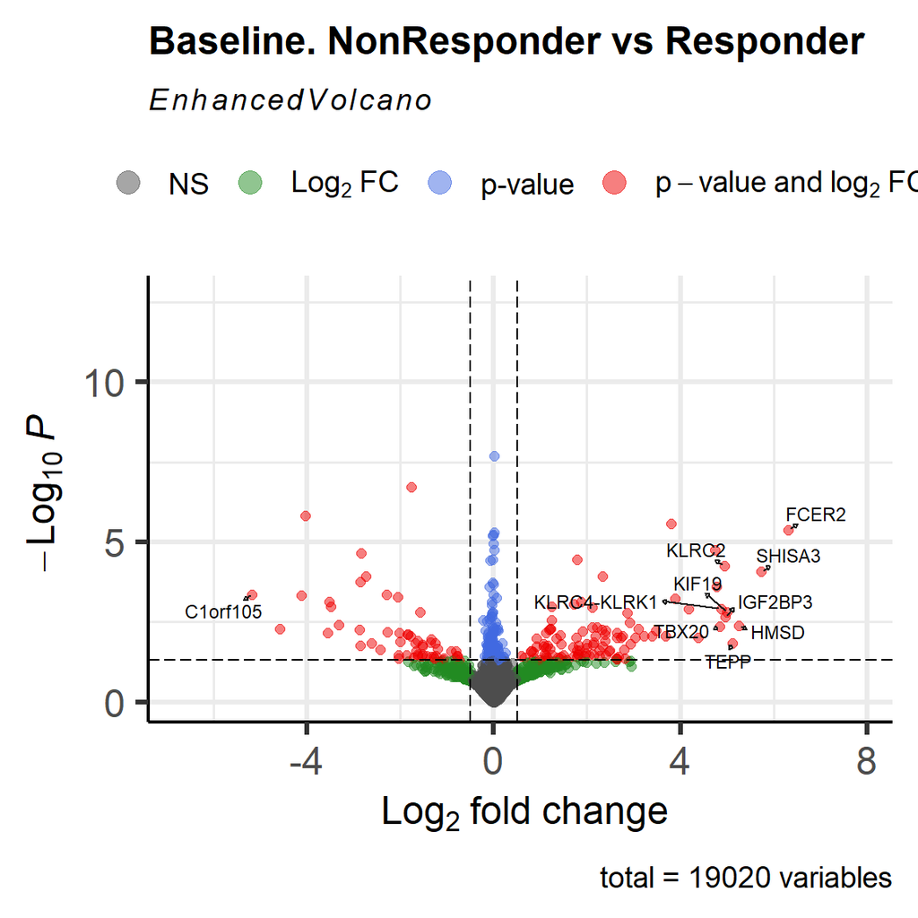

```
## The number of significantly DE genes:
##  158
## The number of down- and up-regulated genes:
##  55 103
## The top up-regulated genes:
##  FCER2 SHISA3 HMSD TEPP KIF19 IGF2BP3 KLRC2 KLRC4-KLRK1 TBX20 CHD5 KLRC3 NYAP2 KLRC4 TTC24 CTSW FSD1 LOC101929107 BMP6 CLEC4E LY75 FCRL3 LOC151174 LOC101928871 C12orf55 MIR378E TCF21 AKR1E2 DHRS9 CDH17 PHYHIP VAT1L S1PR4 CLEC4C KLRK1 ZBED2 SH2D1A INSL3 TNFRSF9 PRKCB LYZ MCTP2 RHOF KLRF1 FAM21B PT…
## The top down-regulated genes:
##  C1orf105 ANGPTL5 FAM189A1 FLJ22184 HOXC13-AS MPV17L TMEM59L ATP1A2 EYA2 PAPSS2 KCNS3 WBSCR27 ALCAM SH3RF2 SGSM1 SELENBP1 HYDIN FAM86FP HAND2 PRIMA1 FAR2 SRCIN1 MUC20 FLNC ZNF219 CCDC149 ARHGEF40 CSPG4 PHLDA2 FAM86JP PLEKHG6 LOC101929513 SGCA HMGN5 TNIK GRTP1 TCHH IRX6 GOLGA2P7 ZNF728 ENAH COL4A2…
```

### Heatmap of Responder vs Nonresponder (Baseline)

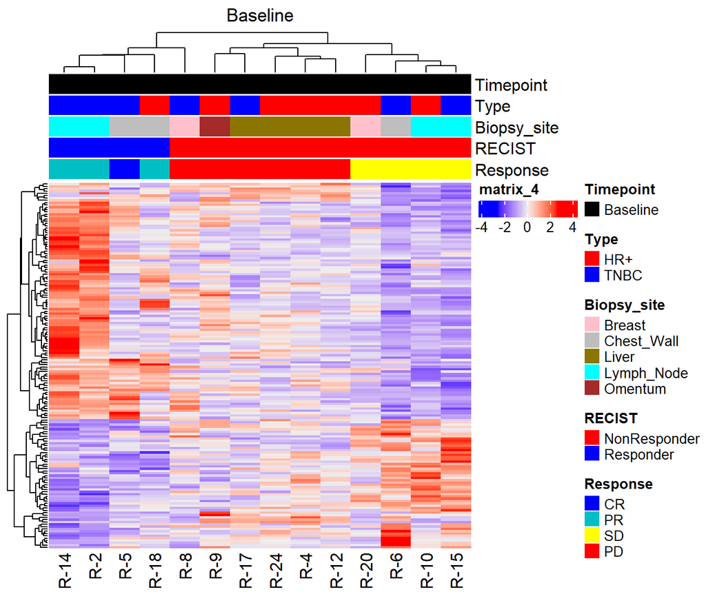

### Heatmap of Hallmark pathways

Responder vs Nonresponder (Baseline)

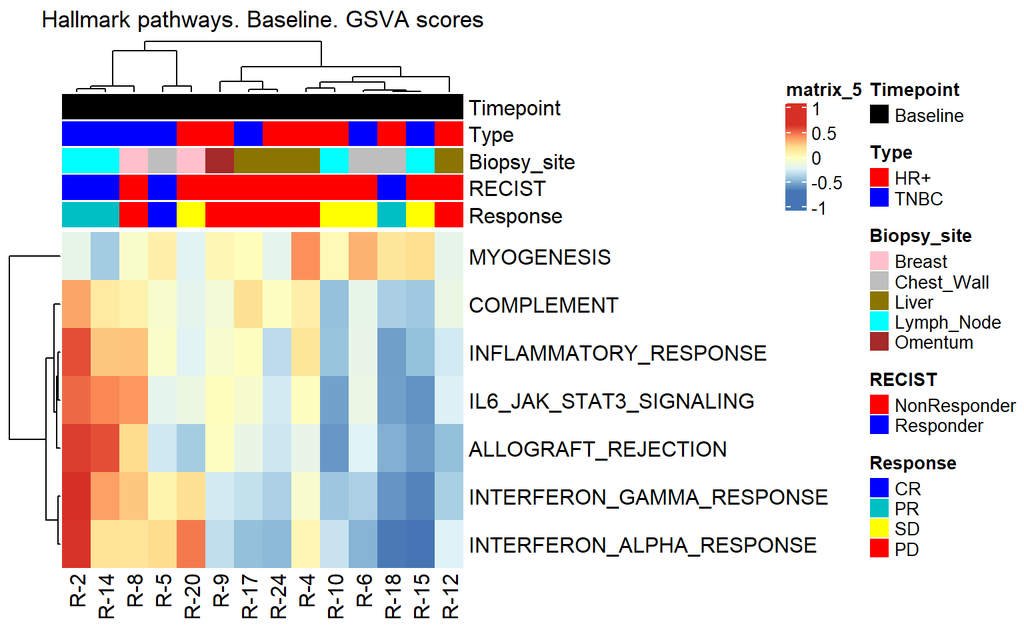

## Responder vs Nonresponder (C1D1)

```
##
## NonResponder    Responder
##           11            5
```

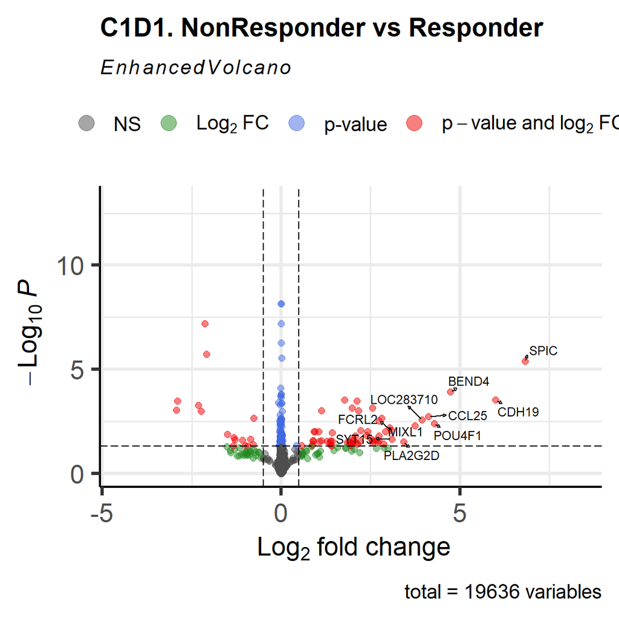

```
## The number of significantly DE genes:
##  75
## The number of down- and up-regulated genes:
##  16 59
## The top up-regulated genes:
##  SPIC CDH19 BEND4 POU4F1 CCL25 LOC283710 MIXL1 PLA2G2D SYT15 FCRL2 MS4A1 ZBED2 TRIM71 AKR1E2 CNR2 AMN BMP6 CXCR5 CD19 PPARGC1A KCNJ10 HIST1H4D GPR114 FCRL3 CXCL9 MORN3 KLRC2 CCND2 MIR378I BAIAP2L2 BLK TNFRSF13C TPTE2 HMSD ACN9 HIST1H4L MGAT3 CD27 KLRC3 TAF7L NINL TCF7 MMP25 HSH2D DRICH1 HIST1H3I …
## The top down-regulated genes:
##  ALK VAX2 ALCAM GHR KCNS3 ADORA3 TREM2 SYPL2 FAM78B ZNF91 FFAR4 ADAMTSL1 ITGB5 MICA LDLRAD4 TCEAL4
```

### Heatmap of Responder vs Nonresponder (C1D1)

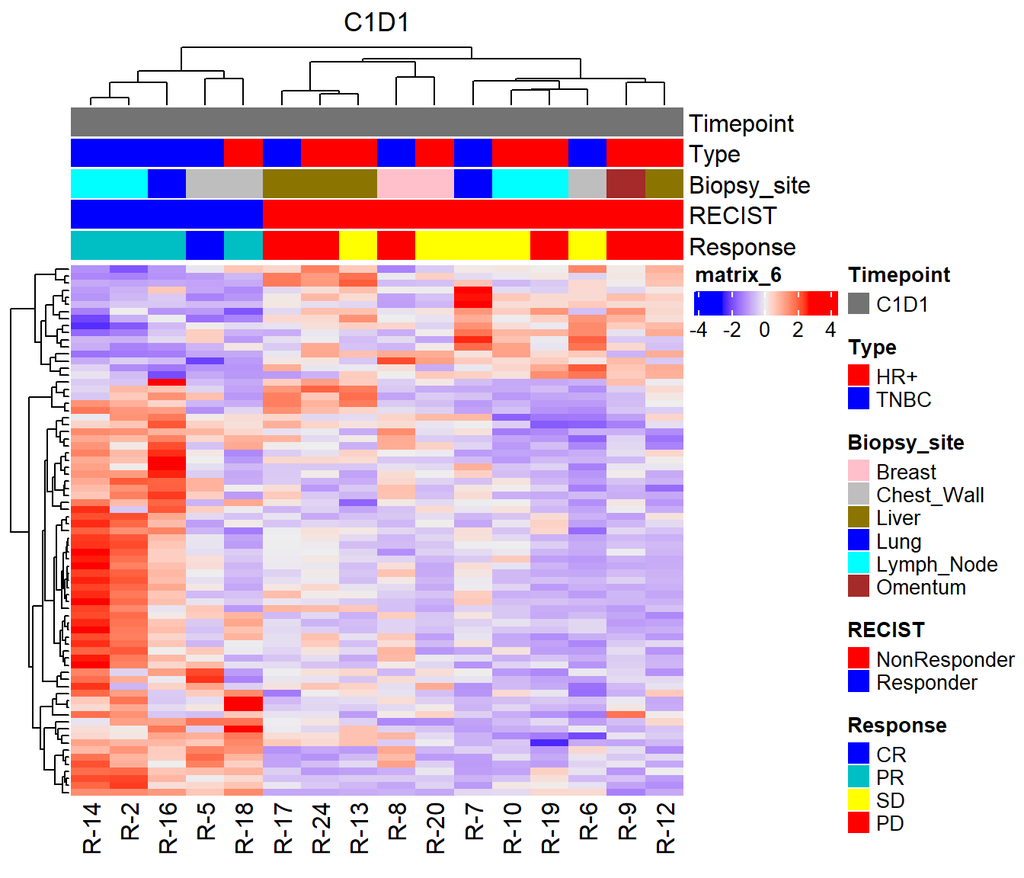

## Responder vs Nonresponder (Week 8)

```
##
## NonResponder    Responder
##            5            2
```

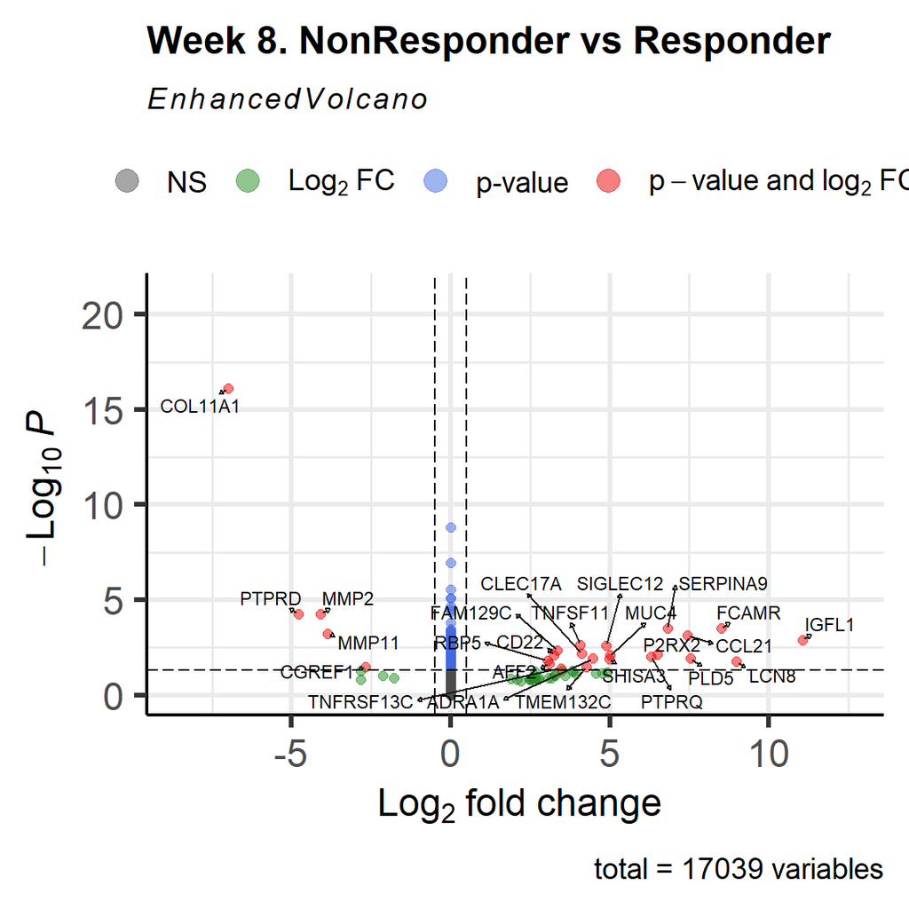

```
## The number of significantly DE genes:
##  25
## The number of down- and up-regulated genes:
##  5 20
## The top up-regulated genes:
##  IGFL1 LCN8 FCAMR PLD5 CCL21 SERPINA9 P2RX2 PTPRQ MUC4 SHISA3 SIGLEC12 ADRA1A TMEM132C CLEC17A TNFSF11 TNFRSF13C FAM129C CD22 AFF2 RBP5
## The top down-regulated genes:
##  COL11A1 PTPRD MMP2 MMP11 CGREF1
```

### Heatmap of Responder vs Nonresponder (Week 8)

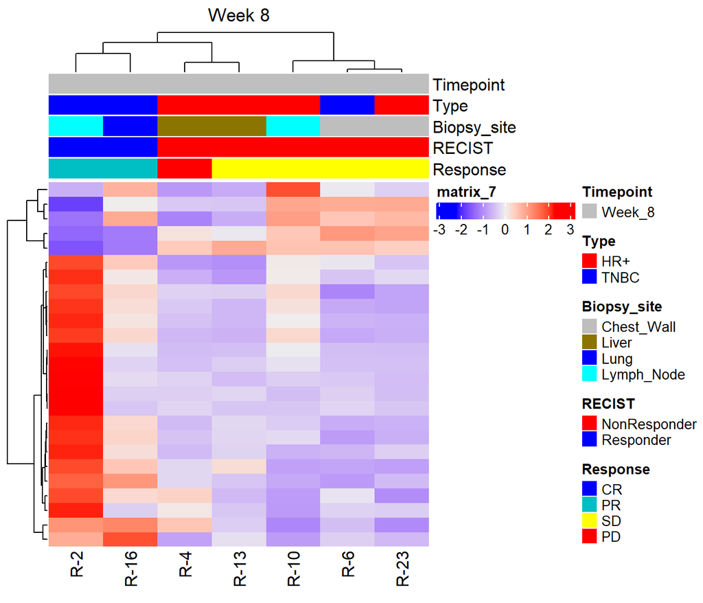

## top 10 gene table

| Baseline_up | Baseline_down | C1D1_up | C1D1_down | Week8_up | Week8_down |
| --- | --- | --- | --- | --- | --- |
| FCER2 | C1orf105 | SPIC | ALK | IGFL1 | COL11A1 |
| SHISA3 | ANGPTL5 | CDH19 | VAX2 | LCN8 | PTPRD |
| HMSD | FAM189A1 | BEND4 | ALCAM | FCAMR | MMP2 |
| TEPP | FLJ22184 | POU4F1 | GHR | PLD5 | MMP11 |
| KIF19 | HOXC13-AS | CCL25 | KCNS3 | CCL21 | CGREF1 |
| IGF2BP3 | MPV17L | LOC283710 | ADORA3 | SERPINA9 |  |
| KLRC2 | TMEM59L | MIXL1 | TREM2 | P2RX2 |  |
| KLRC4-KLRK1 | ATP1A2 | PLA2G2D | SYPL2 | PTPRQ |  |
| TBX20 | EYA2 | SYT15 | FAM78B | MUC4 |  |
| CHD5 | PAPSS2 | FCRL2 | ZNF91 | SHISA3 |  |

# PAM50 subtypes

Predictions were done using the pam50 R package. https://github.com/hoadley-lab/pam50 Parker et al. 2009, https://pubmed.ncbi.nlm.nih.gov/19204204/ Assign subtypes based on the most highly correlated subtype centroid from pre-existing training data.

## Heatmap

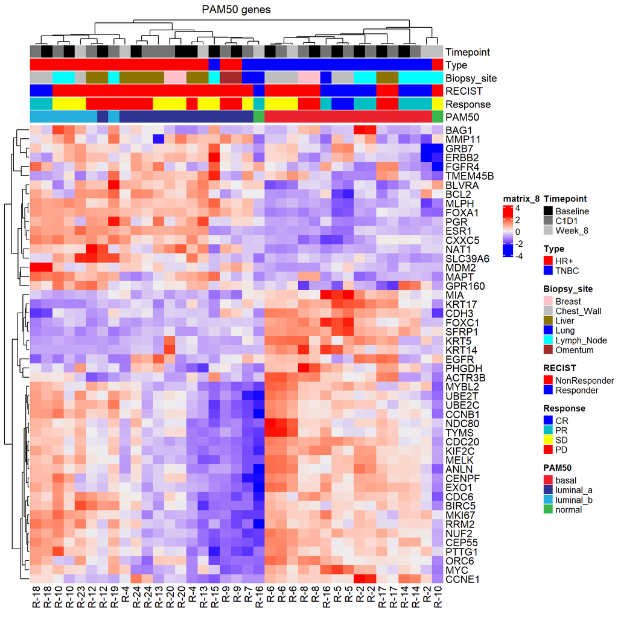

Assign per patient subtype. If a patient doesn’t have a baseline samples, use subsequent time points.

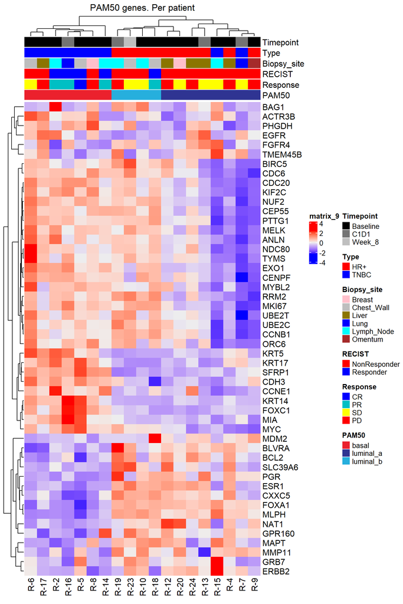

```
## [1] "patient without RNAseq data"
```

```
## [1] "R-1"
```

## Correlation with response

```
##
##             NonResponder Responder
##   basal                3         4
##   luminal_a            8         0
##   luminal_b            3         1
```

```
##
##  Pearson's Chi-squared test
##
## data:  tab
## X-squared = 6.2913, df = 2, p-value = 0.04304
```

```
##
##             HR+ TNBC
##   basal       0    7
##   luminal_a   6    2
##   luminal_b   4    0
```

```
##
##  Pearson's Chi-squared test
##
## data:  tab
## X-squared = 12.983, df = 2, p-value = 0.001516
```

# TNBCtype subtypes

TNBC samples were classified using the Vanderbilt classifier. https://cbc.app.vumc.org/tnbc/

## Assignment using vst values

vstDat_plotting_tnbc.csv was used as an input for the TNBCtype classifier.

The results are in TNBCtype/vst_input_all_samples/

```
## [1] "Samples removed from the TNBCtype analysis:"
```

```
##  [1] "R-18_Baseline"    "R-12_Baseline"    "R-12_Post Run-in" "R-19_Post Run-in"
##  [5] "R-20_Baseline"    "R-20_Post Run-in" "R-2_Baseline"     "R-2_Post Run-in"
##  [9] "R-18_Post Run-in" "R-2_Week 8"       "R-17_Baseline"    "R-17_Post Run-in"
## [13] "R-23_Week 8"      "R-4_Week 8"       "R-24_Baseline"    "R-24_Post Run-in"
## [17] "R-9_Baseline"     "R-7_Post Run-in"  "R-13_Post Run-in" "R-13_Week 8"
## [21] "R-10_Baseline"    "R-10_Week 8"      "R-10_Post Run-in" "R-4_Baseline"
```

|  | subtype | correlation | p.value |
| --- | --- | --- | --- |
| R-5_Baseline | BL1 | 0.607357696296748 | 0 |
| R-5_Post Run-in | BL1 | 0.680956183819704 | 0 |
| R-14_Baseline | IM | 0.692003465119972 | 0 |
| R-14_Post Run-in | IM | 0.646977453370319 | 0 |
| R-6_Baseline | BL1 | 0.555958017519891 | 0 |
| R-6_Post Run-in | BL1 | 0.556658868014031 | 0 |
| R-6_Week 8 | BL1 | 0.485198303535991 | 0 |
| R-8_Baseline | UNS |  |  |
| R-8_Post Run-in | BL2 | 0.301485059131534 | 0 |
| R-16_Post Run-in | MSL | 0.157645235837561 | 0 |

[output cut: 3 more lines]

|  | IM | BL1 | MSL | M | BL2 | LAR |
| --- | --- | --- | --- | --- | --- | --- |
| R-5_Baseline | -0.371 | 0.607 | -0.369 | 0.486 | -0.26 | -0.426 |
| R-5_Post Run-in | 0.116 | 0.681 | -0.546 | -0.021 | -0.3 | -0.358 |
| R-14_Baseline | 0.692 | 0.054 | -0.017 | -0.648 | -0.234 | 0.1 |
| R-14_Post Run-in | 0.647 | -0.099 | 0.147 | -0.622 | -0.05 | 0.115 |
| R-6_Baseline | -0.445 | 0.556 | -0.261 | 0.503 | -0.205 | -0.301 |
| R-6_Post Run-in | -0.43 | 0.557 | -0.276 | 0.474 | -0.188 | -0.301 |
| R-6_Week 8 | -0.088 | 0.485 | -0.247 | 0.227 | -0.108 | -0.265 |
| R-8_Baseline | 0.178 | -0.033 | -0.157 | -0.246 | 0.165 | -0.113 |
| R-8_Post Run-in | -0.054 | -0.027 | -0.221 | -0.069 | 0.301 | -0.109 |
| R-16_Post Run-in | 0.027 | -0.169 | 0.158 | 0.133 | -0.244 | -0.18 |

[output cut: 3 more lines]

```
## [1] 13  3
```

## Heatmap

### per patient

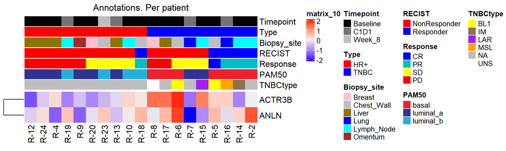

### all samples

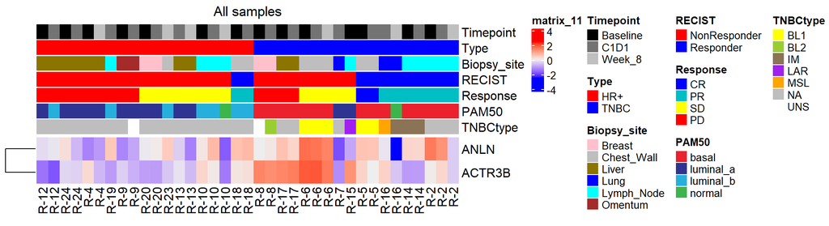

# TME gene sets

## Significant sets in responders vs non-responder at C1D1

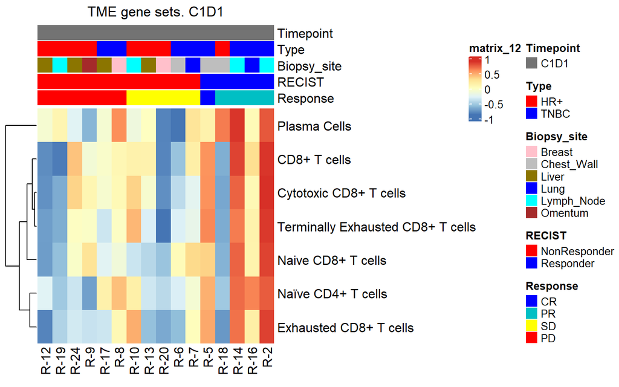

## Significant sets in responders vs non-responder at Week 8

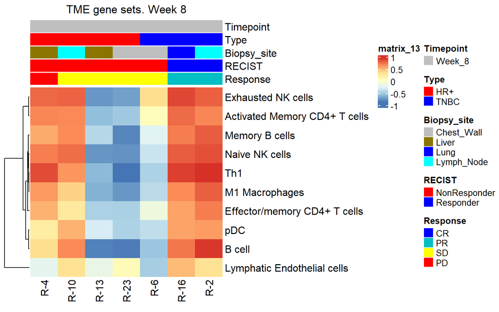